# Data Science Certificate Notes

### Programming Assignment 1: Quiz

[A good reference](https://rstudio-pubs-static.s3.amazonaws.com/220397_d07534a9d3de4d0d87d7df9036602296.html#)

````r
# # Write a function named 'pollutantmean' that calculates the mean of a pollutant (sulfate or nitrate) across a specified list of monitors. The function 'pollutantmean' takes three arguments: 'directory', 'pollutant', and 'id'. Given a vector monitor ID numbers, 'pollutantmean' reads that monitors' particulate matter data from the directory specified in the 'directory' argument and returns the mean of the pollutant across all of the monitors, ignoring any missing values coded as NA. A prototype of the function is as follows
#
# getwd()
#
# pollutantmean <- function(directory,pollutant, id=1:332) {
#
#   full <- NA
#
#   for (x in id){
#   path <- paste("./","data/",directory,"/",sprintf("%.3d",x),".csv",sep="")
#   rcsv <- read.csv(path)
#   full<-rbind(full,rcsv)
#   }
#
#   x<-mean(full[,pollutant],na.rm=T)
#   x
# }
#
# # Test
# pollutantmean("specdata","nitrate", 70:72)
# pollutantmean("specdata","nitrate", 23)
#
# # save the above as a function
#
#
# # Write a function that reads a directory full of files and reports the number of completely observed cases in each data file. The function should return a data frame where the first column is the name of the file and the second column is the number of complete cases. A prototype of this function follows
#
#
# # library(dplyr)
# # complete <- function(directory, id=1:332){
# #
# #    full <-NA
# #
# #    for (x in id){
# #                 path <- paste("./","data/",directory,"/",sprintf("%.3d",x),".csv",sep="")
# #                 rcsv <- read.csv(path)
# #                 full<-rbind(full,rcsv)
# #    }
# #
# #    results <-full %>%
# #                  mutate(a=case_when(((!is.na(sulfate))&(!is.na(nitrate)))~1,TRUE~0)) %>%
# #                  group_by(ID) %>%
# #                  mutate(nobs=sum(a)) %>%
# #                  filter(row_number()==1 & !is.na(ID)) %>%
# #                  ungroup() %>%
# #                  select(ID,nobs)
# #    results<-as.data.frame(results)
# #    results
# # }
# #
# #
# #
# # xx<-complete("specdata",30:25)
# # x<-complete("specdata",3)
# #
# # # Write a function that takes a directory of data files and a threshold for complete cases and calculates the correlation between sulfate and nitrate for monitor locations where the number of completely observed cases (on all variables) is greater than the threshold. The function should return a vector of correlations for the monitors that meet the threshold requirement. If no monitors meet the threshold requirement, then the function should return a numeric vector of length 0. A prototype of this function follows.
# #
# # source("./2_R Programming/complete.R")
# # corr <- function(directory, threshold=0){
# #
# #    for (x in 1:332){
# #                 path <- paste("./","data/",directory,"/",sprintf("%.3d",x),".csv",sep="")
# #                 rcsv <- read.csv(path)
# #                 full<-rbind(full,rcsv)
# #    }
# #
# #    nobs <- complete(directory)
# #
# #    full_nobs <- left_join(full,nobs, by="ID")
# #
# #    results <-    full_nobs %>%
# #                  group_by(ID) %>%
# #                  mutate(correlation=cor(sulfate,nitrate,use="na.or.complete")) %>%
# #                  filter(row_number()==1) %>%
# #                  ungroup() %>%
# #                  select(ID,nobs,correlation) %>%
# #                  filter(nobs>threshold)
# #
# #    vec <-results$correlation
# # }
# #
# #
# # cr<-corr("specdata")
# #
# # summary(cr)
# # length(cr)
# #
# # cr<-corr("specdata",5000)
# # summary(cr)
#
# ```
#
# QUIZ
#
# ```{r}
# # # 1 might be faster
# # pollutantmean <- function(directory, pollutant, id = 1:332) {
# #     ## 'directory' is a character vector of length 1 indicating
# #     ## the location of the CSV files
# #
# #     ## 'pollutant' is a character vector of length 1 indicating
# #     ## the name of  the pollutant for which we will calcultate the
# #     ## mean; either "sulfate" or "nitrate"
# #
# #     ## 'id' is an integer vector indicating the monitor ID numbers
# #     ## to be used
# #
# #     ## Return the mean of the pollutant across all monitors list
# #     ## in the 'id' vector (ignoring NA values)
# #     ## NOTE: Do not round the result
# #     means <- c()
# #
# #     for(monitor in id){
# #         path <- paste(getwd(), "/", directory, "/", sprintf("%03d", monitor), ".csv", sep = "")
# #         monitor_data <- read.csv(path)
# #         interested_data <- monitor_data[pollutant]
# #         means <- c(means, interested_data[!is.na(interested_data)])
# #     }
# #
# #     mean(means)
# # }
# #
# # # 3 might be faster
# # corr <- function(directory, threshold = 0){
# #     ## 'directory' is a character vector of length 1 indicating
# #     ## the location of the CSV files
# #
# #     ## 'threshold' is a numeric vector of length 1 indicating the
# #     ## number of completely observed observations (on all
# #     ## variables) requi?red to compute the correlation between
# #     ## nitrate and sulfate; the default is 0
# #
# #     ## Return a numeric vector of correlations
# #     ## NOTE: Do not round the result!
# #     cor_results <- numeric(0)
# #
# #     complete_cases <- complete(directory)
# #     complete_cases <- complete_cases[complete_cases$nobs>=threshold, ]
# #     #print(complete_cases["id"])
# #     #print(unlist(complete_cases["id"]))
# #     #print(complete_cases$id)
# #
# #     if(nrow(complete_cases)>0){
# #         for(monitor in complete_cases$id){
# #             path <- paste(getwd(), "/", directory, "/", sprintf("%03d", monitor), ".csv", sep = "")
# #             #print(path)
# #             monitor_data <- read.csv(path)
# #             #print(monitor_data)
# #             interested_data <- monitor_data[(!is.na(monitor_data$sulfate)), ]
# #             interested_data <- interested_data[(!is.na(interested_data$nitrate)), ]
# #             sulfate_data <- interested_data["sulfate"]
# #             nitrate_data <- interested_data["nitrate"]
# #             cor_results <- c(cor_results, cor(sulfate_data, nitrate_data))
# #         }
# #     }
# #     cor_results
# # }
#
#
# source("./2_R Programming/pollutantmean.R")
# source("./2_R Programming/complete.R")
# source("./2_R Programming/corr.R")
#
# pollutantmean("specdata", "sulfate", 1:10)
# pollutantmean("specdata", "nitrate", 70:72)
# pollutantmean("specdata", "sulfate", 34)
# pollutantmean("specdata", "nitrate")
#
# cc <- complete("specdata", c(6, 10, 20, 34, 100, 200, 310))
# print(cc$nobs)
#
# cc <- complete("specdata", 54)
# print(cc$nobs)
#
# #2  FASTER musch better
# complete <- function(directory, id = 1:332){
#     ## 'director' is a character vector of length 1 indicating
#     ## the location of the CSV files
#
#     ## 'id' is an integer vector indicating the monitor ID numbers
#     ## to be used
#
#     ## Return a data frame of the from:
#     ## id nobs
#     ## 1  117
#     ## 2  1041
#     ## ...
#     ## where 'id' is the monitor ID number and 'nobs' is the
#     ## number of complete cases
#     results <- data.frame(id=numeric(0), nobs=numeric(0))
#     for(monitor in id){
#         path <- paste("./","data/",directory,"/",sprintf("%.3d",monitor),".csv",sep="")
#         monitor_data <- read.csv(path)
#         interested_data <- monitor_data[(!is.na(monitor_data$sulfate)), ]
#         interested_data <- interested_data[(!is.na(interested_data$nitrate)), ]
#         nobs <- nrow(interested_data)
#         results <- rbind(results, data.frame(id=monitor, nobs=nobs))
#     }
#     results
# }
#
# RNGversion("3.5.1")
# set.seed(42)
# cc <- complete("specdata", 332:1)
# use <- sample(332, 10)
# print(cc[use, "nobs"])
#
# cr <- corr("specdata")
# cr <- sort(cr)
# RNGversion("3.5.1")
# set.seed(868)
# out <- round(cr[sample(length(cr), 5)], 4)
# print(out)
#
# cr <- corr("specdata", 129)
# cr <- sort(cr)
# n <- length(cr)
# RNGversion("3.5.1")
# set.seed(197)
# out <- c(n, round(cr[sample(n, 5)], 4))
# print(out)
#
# cr <- corr("specdata", 2000)
# n <- length(cr)
# cr <- corr("specdata", 1000)
# cr <- sort(cr)
# print(c(n, round(cr, 4)))
#
````

## Week 2.3 Loop Functions and Debugging

### Loop function-lapply

- lapply: loop over a list and evaluate a function on each element
- sapply: same as lapply but try to simplify the result
- apply: apply a function over the margins of an array
- tapply: apply a function over subsets of a vector
- mapply: multivariate version of lapply

```r
# lapply always returns a list , regardless of the class of the input

x <-list(a=1:5,b=rnorm(10))

lapply(x,mean)
```

```
## $a
## [1] 3
##
## $b
## [1] -0.1570395
```

```r
# anaymous function for extracting the first column of each matrix
x <-list(a=matrix(1:4, 2,2), b=matrix(1:6,3,2))
x
```

```
## $a
##      [,1] [,2]
## [1,]    1    3
## [2,]    2    4
##
## $b
##      [,1] [,2]
## [1,]    1    4
## [2,]    2    5
## [3,]    3    6
```

```r
lapply(x,function(elt) elt[,1])
```

```
## $a
## [1] 1 2
##
## $b
## [1] 1 2 3
```

sapply will try to simplify the result of lapply if possible. * if the result is a list where every element is length 1, then a vector is returned * if the result is a list where every eleemnent is a vector of the same length(>1), a matrix is returned. * if it can’t figure things out, a list is returend.

### Loop Functions-apply

apply is used to evaluate a function (often an anonymous one) over the margins of an array. * if is most often used to apply a fucntion to the rows or columns of a matrix * if can be sued with general arrays,e.g. taking the average of an array of matrices * if is not really faster than writing a loop, but it works in one line!

array is a vector has dimension attached to it. a matrix is a two dimensional array.

```r
x <-matrix(rnorm(200),20,10)

# 2 means pass the function to each column
apply(x,2,mean)
```

```
##  [1]  0.07186279 -0.16255015 -0.05288058 -0.13245305 -0.19839742 -0.16006518
##  [7] -0.03917661  0.02098007 -0.47008309  0.11003800
```

```r
# 1 means pass the function to each row
apply(x,1,sum)
```

```
##  [1] -3.33787152 -6.91172095 -3.77757837 -1.89387923 -3.84946811  4.95433380
##  [7] -1.53978520 -1.96883149 -3.24460648 -2.20684923  3.43857629  4.13485756
## [13] -1.71139253 -2.35874828 -1.44634381 -3.28274053  0.03209805  2.50910202
## [19] -2.99441233  5.20075578
```

```r
# For sums and means of matrix dimensions, we have some shortcuts.
 # rowSums=apply(x,1,sum)
 # rowMeans=apply(x,1,mean)
 # colSums=apply(x,2,sum)
 # colMeans=apply(x,2,mean)

x <-matrix(rnorm(200),20,10)
apply(x,1,quantile,probs=c(0.25,0.75)) # for each row, two line report
```

```
##            [,1]      [,2]       [,3]      [,4]       [,5]       [,6]       [,7]
## 25% -0.92402820 0.1207803 -1.0290207 -1.146032 -0.5063523 -0.7177150 -0.8886430
## 75% -0.03906335 1.3682528  0.4924368  1.120633  0.3577959  0.5457819  0.3891865
##           [,8]       [,9]       [,10]      [,11]       [,12]      [,13]
## 25% -0.6195043 -0.6162145 -0.03486059 -0.8479715 -0.57904393 -0.8713716
## 75%  0.5074967  0.4675055  0.84313526 -0.1763104  0.09069752  0.1375723
##          [,14]      [,15]      [,16]      [,17]      [,18]      [,19]
## 25% -0.4157763 -0.2378884 -0.5124678 -0.5835118 -0.4809191 -0.9249567
## 75%  0.6513045  0.4800001  0.6804443  0.7939903  0.2342394  0.8104196
##          [,20]
## 25% -1.7214834
## 75%  0.3961255
```

```r
a <- array(rnorm(2*2*10),c(2,2,10))
a
```

```
## , , 1
##
##            [,1]        [,2]
## [1,] -0.9495108 -1.68576698
## [2,]  0.6876029  0.06177374
##
## , , 2
##
##            [,1]       [,2]
## [1,] 0.08672286  1.1712200
## [2,] 0.35038811 -0.9002966
##
## , , 3
##
##              [,1]       [,2]
## [1,] -0.494081800  0.6471169
## [2,]  0.007849016 -0.2910470
##
## , , 4
##
##           [,1]       [,2]
## [1,] 0.5566535 -0.4379027
## [2,] 0.7978932 -1.7690092
##
## , , 5
##
##            [,1]        [,2]
## [1,]  0.5991101 -1.16551763
## [2,] -0.5660212 -0.08309749
##
## , , 6
##
##             [,1]       [,2]
## [1,] -0.05870913 -0.2146208
## [2,]  2.62335989 -0.8361035
##
## , , 7
##
##           [,1]        [,2]
## [1,] -1.055646 -0.10677962
## [2,] -1.188193 -0.07918718
##
## , , 8
##
##            [,1]       [,2]
## [1,] -1.7046732  0.8663319
## [2,] -0.1774443 -2.1163028
##
## , , 9
##
##           [,1]       [,2]
## [1,] -1.597257 -0.9310851
## [2,] -1.433120 -2.6505826
##
## , , 10
##
##            [,1]       [,2]
## [1,]  0.8760552 -0.6171808
## [2,] -0.1715564  0.1351121
```

```r
apply(a,c(1,2),mean) # collapse the third dimension.
```

```
##             [,1]       [,2]
## [1,] -0.37413363 -0.2474185
## [2,]  0.09307583 -0.8528741
```

```r
rowMeans(a, dims=2)
```

```
##             [,1]       [,2]
## [1,] -0.37413363 -0.2474185
## [2,]  0.09307583 -0.8528741
```

### Loop Functions-mapply

mapply is a multivariate apply of sorts which applies a function in parallel over a set of arguments.

```r
# The following is tedious to type

list(rep(1,4),rep(2,3),rep(3,2),rep(4,1))
```

```
## [[1]]
## [1] 1 1 1 1
##
## [[2]]
## [1] 2 2 2
##
## [[3]]
## [1] 3 3
##
## [[4]]
## [1] 4
```

```r
# instead we can do

mapply(rep, 1:4,4:1)
```

```
## [[1]]
## [1] 1 1 1 1
##
## [[2]]
## [1] 2 2 2
##
## [[3]]
## [1] 3 3
##
## [[4]]
## [1] 4
```

vectorizing a function

```r
noise <- function(n,mean,sd) {
  rnorm(n,mean,sd)
}

mapply(noise,1:5,1:5,2)
```

```
## [[1]]
## [1] 1.992718
##
## [[2]]
## [1] 1.466869 1.885821
##
## [[3]]
## [1] 2.092093 4.380103 1.164265
##
## [[4]]
## [1] 2.665595 3.609917 6.450387 3.554461
##
## [[5]]
## [1] 1.343907 5.845906 1.035375 6.337340 7.135246
```

### Loop Functions-tapply

tapply is used to apply a function over subsets of a vector.

```r
# take group means
str(tapply)
```

```
## function (X, INDEX, FUN = NULL, ..., default = NA, simplify = TRUE)
```

```r
# x is a vector
# index is a factor or a list of factors
# fun is a function to be applied
# simplify, should we simplify the results?

x <- c(rnorm(10),runif(10),rnorm(10,1))
x
```

```
##  [1]  1.1968818 -0.7659589  1.9232298 -0.3082073  1.1087775  1.4036784
##  [7]  0.2212531 -1.8447670 -0.1937808 -0.8524047  0.4859534  0.7656585
## [13]  0.8294396  0.1737703  0.4087409  0.5632937  0.8370136  0.7647717
## [19]  0.2478949  0.9635387  1.0417743 -0.6782090  0.9330698  1.8452650
## [25]  0.4239665 -0.2852847  1.2240401  1.1556565  1.5318632  1.3590955
```

```r
f <- gl(3,10) # generate factor level
f
```

```
##  [1] 1 1 1 1 1 1 1 1 1 1 2 2 2 2 2 2 2 2 2 2 3 3 3 3 3 3 3 3 3 3
## Levels: 1 2 3
```

```r
tapply(x,f,mean)
```

```
##         1         2         3
## 0.1888702 0.6040075 0.8551237
```

```r
tapply(x,f,mean, simplify=F)
```

```
## $`1`
## [1] 0.1888702
##
## $`2`
## [1] 0.6040075
##
## $`3`
## [1] 0.8551237
```

```r
tapply(x,f,range)
```

```
## $`1`
## [1] -1.844767  1.923230
##
## $`2`
## [1] 0.1737703 0.9635387
##
## $`3`
## [1] -0.678209  1.845265
```

### Loop Funcitons- split

split takes a vector or other objects and splits it into groups determined by a factor or list of factors

```r
str(split)
```

```
## function (x, f, drop = FALSE, ...)
```

```r
# x is a vector (or) list or data frame
# f is a factor (or coerced to one) or a list of factors
# drop indicates whether empty factors levels should be dropped

x <- c(rnorm(10), runif(10), rnorm(10,1))

f <- gl(3,10)

split(x,f) # split always return a list back so you can use lapply or sapply
```

```
## $`1`
##  [1]  1.4725537  1.3016814  0.6278215  2.1818379  1.0098134  0.5813746
##  [7] -1.1454289  0.8234438 -0.7611045 -0.3069324
##
## $`2`
##  [1] 0.480153442 0.626433817 0.100603033 0.525253778 0.152616465 0.464877880
##  [7] 0.189535776 0.003542563 0.350775000 0.018257902
##
## $`3`
##  [1]  0.63145507  1.37796164  1.04724384  0.82703807  2.51505103  2.07807092
##  [7] -0.03561022  1.87004211  0.55052078  1.57460423
```

```r
# a common idiom is split followed by an lapply

# The following two are the same.
lapply(split(x,f),mean)
```

```
## $`1`
## [1] 0.578506
##
## $`2`
## [1] 0.291205
##
## $`3`
## [1] 1.243638
```

```r
tapply(x,f,mean,simplify=F)
```

```
## $`1`
## [1] 0.578506
##
## $`2`
## [1] 0.291205
##
## $`3`
## [1] 1.243638
```

```r
library(datasets)
head(airquality)
```

```
##   Ozone Solar.R Wind Temp Month Day
## 1    41     190  7.4   67     5   1
## 2    36     118  8.0   72     5   2
## 3    12     149 12.6   74     5   3
## 4    18     313 11.5   62     5   4
## 5    NA      NA 14.3   56     5   5
## 6    28      NA 14.9   66     5   6
```

```r
# calucualte the mean by group

# 1 first split the data frame into monthly pieces
s <- split(airquality, airquality$Month)
lapply(s, function(x) colMeans(x[,c("Ozone", "Solar.R", "Wind")]))
```

```
## $`5`
##    Ozone  Solar.R     Wind
##       NA       NA 11.62258
##
## $`6`
##     Ozone   Solar.R      Wind
##        NA 190.16667  10.26667
##
## $`7`
##      Ozone    Solar.R       Wind
##         NA 216.483871   8.941935
##
## $`8`
##    Ozone  Solar.R     Wind
##       NA       NA 8.793548
##
## $`9`
##    Ozone  Solar.R     Wind
##       NA 167.4333  10.1800
```

```r
sapply(s, function(x) colMeans(x[,c("Ozone", "Solar.R", "Wind")]))
```

```
##                5         6          7        8        9
## Ozone         NA        NA         NA       NA       NA
## Solar.R       NA 190.16667 216.483871       NA 167.4333
## Wind    11.62258  10.26667   8.941935 8.793548  10.1800
```

```r
sapply(s, function(x) colMeans(x[,c("Ozone", "Solar.R", "Wind")],na.rm=T))
```

```
##                 5         6          7          8         9
## Ozone    23.61538  29.44444  59.115385  59.961538  31.44828
## Solar.R 181.29630 190.16667 216.483871 171.857143 167.43333
## Wind     11.62258  10.26667   8.941935   8.793548  10.18000
```

```r
# Splitting on more than one level

x <- rnorm(10)
f1 <- gl(2,5)
f2 <- gl(5,2)
f1
```

```
##  [1] 1 1 1 1 1 2 2 2 2 2
## Levels: 1 2
```

```r
f2
```

```
##  [1] 1 1 2 2 3 3 4 4 5 5
## Levels: 1 2 3 4 5
```

```r
x
```

```
##  [1] -0.46307041 -2.06415124 -1.16259316  0.48420879  0.03470015  1.38108613
##  [7] -0.55198210  1.23223906  0.89422950  1.32919552
```

```r
y <-data.frame(x,f1,f2)
y
```

```
##              x f1 f2
## 1  -0.46307041  1  1
## 2  -2.06415124  1  1
## 3  -1.16259316  1  2
## 4   0.48420879  1  2
## 5   0.03470015  1  3
## 6   1.38108613  2  3
## 7  -0.55198210  2  4
## 8   1.23223906  2  4
## 9   0.89422950  2  5
## 10  1.32919552  2  5
```

```r
interaction(f1,f2) # interaction computes a factor which represents the interaction of the given factors
```

```
##  [1] 1.1 1.1 1.2 1.2 1.3 2.3 2.4 2.4 2.5 2.5
## Levels: 1.1 2.1 1.2 2.2 1.3 2.3 1.4 2.4 1.5 2.5
```

```r
# interactions can create empty levels

str(split(x,list(f1,f2))) # it will do the interaction function automatically.
```

```
## List of 10
##  $ 1.1: num [1:2] -0.463 -2.064
##  $ 2.1: num(0)
##  $ 1.2: num [1:2] -1.163 0.484
##  $ 2.2: num(0)
##  $ 1.3: num 0.0347
##  $ 2.3: num 1.38
##  $ 1.4: num(0)
##  $ 2.4: num [1:2] -0.552 1.232
##  $ 1.5: num(0)
##  $ 2.5: num [1:2] 0.894 1.329
```

```r
# Empty levels can be dropped.

str(split(x,list(f1,f2),drop=TRUE))
```

```
## List of 6
##  $ 1.1: num [1:2] -0.463 -2.064
##  $ 1.2: num [1:2] -1.163 0.484
##  $ 1.3: num 0.0347
##  $ 2.3: num 1.38
##  $ 2.4: num [1:2] -0.552 1.232
##  $ 2.5: num [1:2] 0.894 1.329
```

### Debugging Tools- Diagnosing the Problem

Debugging tool built in R

indications that something’s not right * message: A generic notification/diagnostic message produced by the message function; execution of the function continues * warning an indicaiton that something is wrong but not necessarily fatal; execution of the function continues; generated by the warning funciton * error: an indication that a fatal problem has occurred; execution stops; produced by the stop funciton * condition: a generic concept for indicating that something uenexpected can occur; programmers can create their own conditions

```r
# log(-1) an error will return

printmessage <- function(x) {
  if(x>0)
    print("x is greater than zero")
  else
    print("x is less than or equal to zero")
  invisible(x) # the object returned does not get printed in console.
}

printmessage(1)
```

```
## [1] "x is greater than zero"
```

```r
# printmessage(NA) an error will return because you can not make a comparision whethaet NA is greater than zero.

# how to fix it

printmessage2 <- function(x) {
  if(is.na(x))
    print("x is a missing value!")
  else if(x>0)
    print("x is greater than zero")
  else
    print("x is less than or equal to zero")
  invisible(x)
}

printmessage2(NA)
```

```
## [1] "x is a missing value!"
```

How do you know that something is wrong with your function?

- What was your input? How did you call the function?
- What were you expecting? Output, messages, other results?
- What did you get?
- How does what you get differ from what you were expecting?
- Were you expectations correct in the first place?
- Can you reproduce the problem(exactly)

### Debugging Tools - Basic Tools

The primary tools for debugging funcitons in R are * traceback: prints out the function call stack after an error occurs; does nothing if there’s no erro * debug: flags a function for “debug” mode which allows you to step through execution of a function one line at a time. * browser: suspends the execution of a funtion whever it is called and puts the function in debug mode * trace: allows you to insert debugging code into a function a specific places * recover: allows you to modifi=y the error behavior so that you can browse the funciton call stack.

These are interactive tools specifically designed to allow you to pick through a funciton. There’s also the more blunt technique of inserting print/cat statements in the function.

### Debugging Tools - Using the Tools

```r
# mean(xx) give a warning
# mean(xxx)
# traceback() # traceback give you the most recent error.
```

### Quiz

```r
library(datasets)
data(iris)
?iris

head(iris)
```

```
##   Sepal.Length Sepal.Width Petal.Length Petal.Width Species
## 1          5.1         3.5          1.4         0.2  setosa
## 2          4.9         3.0          1.4         0.2  setosa
## 3          4.7         3.2          1.3         0.2  setosa
## 4          4.6         3.1          1.5         0.2  setosa
## 5          5.0         3.6          1.4         0.2  setosa
## 6          5.4         3.9          1.7         0.4  setosa
```

```r
# In this dataset, what is the mean of 'Sepal.Length' for the species virginica?
tapply(iris$Sepal.Length,iris$Species,mean)
```

```
##     setosa versicolor  virginica
##      5.006      5.936      6.588
```

```r
# Continuing with the 'iris' dataset from the previous Question, what R code returns a vector of the means of the variables 'Sepal.Length', 'Sepal.Width', 'Petal.Length', and 'Petal.Width'?

colMeans(iris[,1:4])
```

```
## Sepal.Length  Sepal.Width Petal.Length  Petal.Width
##     5.843333     3.057333     3.758000     1.199333
```

```r
apply(iris[,1:4],2,mean)
```

```
## Sepal.Length  Sepal.Width Petal.Length  Petal.Width
##     5.843333     3.057333     3.758000     1.199333
```

```r
library(datasets)
data(mtcars)

?mtcars

head(mtcars)
```

```
##                    mpg cyl disp  hp drat    wt  qsec vs am gear carb
## Mazda RX4         21.0   6  160 110 3.90 2.620 16.46  0  1    4    4
## Mazda RX4 Wag     21.0   6  160 110 3.90 2.875 17.02  0  1    4    4
## Datsun 710        22.8   4  108  93 3.85 2.320 18.61  1  1    4    1
## Hornet 4 Drive    21.4   6  258 110 3.08 3.215 19.44  1  0    3    1
## Hornet Sportabout 18.7   8  360 175 3.15 3.440 17.02  0  0    3    2
## Valiant           18.1   6  225 105 2.76 3.460 20.22  1  0    3    1
```

```r
# How can one calculate the average miles per gallon (mpg) by number of cylinders in the car (cyl)? Select all that apply.


sapply(split(mtcars$mpg, mtcars$cyl), mean)
```

```
##        4        6        8
## 26.66364 19.74286 15.10000
```

```r
with(mtcars, tapply(mpg, cyl, mean))
```

```
##        4        6        8
## 26.66364 19.74286 15.10000
```

```r
tapply(mtcars$mpg, mtcars$cyl, mean)
```

```
##        4        6        8
## 26.66364 19.74286 15.10000
```

```r
# what is the absolute difference between the average horsepower of 4-cylinder cars and the average horsepower of 8-cylinder cars?
x<-tapply(mtcars$hp, mtcars$cyl, mean)
x
```

```
##         4         6         8
##  82.63636 122.28571 209.21429
```

```r
x[1]-x[3]
```

```
##         4
## -126.5779
```

```r
debug(ls)
ls()
```

[output not shown]

```
##  [1] "a"             "above"         "above10"       "add2"
##  [5] "age"           "columnmean"    "count"         "cube"
##  [9] "data1"         "data2"         "data3"         "data4"
## [13] "datestring"    "f"             "f1"            "f2"
## [17] "good"          "i"             "iris"          "j"
## [21] "letter"        "m"             "make.power"    "msg"
## [25] "mtcars"        "myplot"        "name"          "noise"
## [29] "p"             "printmessage"  "printmessage2" "s"
## [33] "suqre"         "u"             "x"             "y"
## [37] "z"
```

### Programming Assignment

Example: Caching the Mean of a Vector

The first function, makeVector creates a special “vector”, which is really a list containing a function to

1. set the value of the vector
2. get the value of the vector
3. set the value of the mean
4. get the value of the mean

```r
makeVector <- function(x = numeric()) {
        m <- NULL
        set <- function(y) {
                x <<- y
                m <<- NULL
        }
        get <- function() x # since the symbol x is not defined within get(), R retrieves it from the parent environment
        setmean <- function(mean) m <<- mean # the code uses the <<- form of the assignment operator to assign the input argument to the value of m in the parent environment.
        getmean <- function() m
        list(set = set, get = get,
             setmean = setmean,
             getmean = getmean)
}

makeVector(1:2)
```

```
## $set
## function(y) {
##                 x <<- y
##                 m <<- NULL
##         }
## <environment: 0x1199ca388>
##
## $get
## function() x
## <environment: 0x1199ca388>
##
## $setmean
## function(mean) m <<- mean
## <environment: 0x1199ca388>
##
## $getmean
## function() m
## <environment: 0x1199ca388>
```

```r
cachemean <- function(x, ...) {
        m <- x$getmean()
        if(!is.null(m)) {
                message("getting cached data")
                return(m)
        }
        data <- x$get()
        m <- mean(data, ...)
        x$setmean(m)
        m
}

aVector <-makeVector(1:10)
```

[output not shown]

[output cut: 615 more lines]

[output not shown]

```r
aVector$get()
```

```
##  [1]  1  2  3  4  5  6  7  8  9 10
```

```r
aVector$getmean()
```

[output not shown]

```r
aVector$set(30:50)
cachemean(aVector)
```

```
## [1] 40
```

```r
aVector$getmean()
```

```
## [1] 40
```

## Simulation & Profiling

### str: compactly display the internal structure of an R object

- A diagnostic function and an alternative to ‘summary’
- It is especially well suited to compactly display the (abbreviated) contents of (possibly nested) lists.
- Roughly one line per basic object

```r
str(str)
```

```
## function (object, ...)
```

```r
str(lm)
```

```
## function (formula, data, subset, weights, na.action, method = "qr", model = TRUE,
##     x = FALSE, y = FALSE, qr = TRUE, singular.ok = TRUE, contrasts = NULL,
##     offset, ...)
```

```r
x<-rnorm(100,2,4)
str(x)
```

```
##  num [1:100] 1.99 6.55 1.77 8.64 -2.48 ...
```

```r
summary(x)
```

```
##    Min. 1st Qu.  Median    Mean 3rd Qu.    Max.
## -6.0342  0.2191  2.6266  2.5768  5.0299 10.9266
```

```r
f <- gl(40, 10)
str(f)
```

```
##  Factor w/ 40 levels "1","2","3","4",..: 1 1 1 1 1 1 1 1 1 1 ...
```

```r
library(datasets)
head(airquality)
```

```
##   Ozone Solar.R Wind Temp Month Day
## 1    41     190  7.4   67     5   1
## 2    36     118  8.0   72     5   2
## 3    12     149 12.6   74     5   3
## 4    18     313 11.5   62     5   4
## 5    NA      NA 14.3   56     5   5
## 6    28      NA 14.9   66     5   6
```

```r
str(airquality)
```

```
## 'data.frame':    153 obs. of  6 variables:
##  $ Ozone  : int  41 36 12 18 NA 28 23 19 8 NA ...
##  $ Solar.R: int  190 118 149 313 NA NA 299 99 19 194 ...
##  $ Wind   : num  7.4 8 12.6 11.5 14.3 14.9 8.6 13.8 20.1 8.6 ...
##  $ Temp   : int  67 72 74 62 56 66 65 59 61 69 ...
##  $ Month  : int  5 5 5 5 5 5 5 5 5 5 ...
##  $ Day    : int  1 2 3 4 5 6 7 8 9 10 ...
```

```r
m <- matrix(rnorm(100), 10, 10)
str(m) # give you the observation in first column
```

```
##  num [1:10, 1:10] -0.4571 0.2871 -0.0637 0.4939 -1.5291 ...
```

```r
s<-split(airquality, airquality$Month)
str(s)
```

```
## List of 5
##  $ 5:'data.frame':   31 obs. of  6 variables:
##   ..$ Ozone  : int [1:31] 41 36 12 18 NA 28 23 19 8 NA ...
##   ..$ Solar.R: int [1:31] 190 118 149 313 NA NA 299 99 19 194 ...
##   ..$ Wind   : num [1:31] 7.4 8 12.6 11.5 14.3 14.9 8.6 13.8 20.1 8.6 ...
##   ..$ Temp   : int [1:31] 67 72 74 62 56 66 65 59 61 69 ...
##   ..$ Month  : int [1:31] 5 5 5 5 5 5 5 5 5 5 ...
##   ..$ Day    : int [1:31] 1 2 3 4 5 6 7 8 9 10 ...
##  $ 6:'data.frame':   30 obs. of  6 variables:
##   ..$ Ozone  : int [1:30] NA NA NA NA NA NA 29 NA 71 39 ...
##   ..$ Solar.R: int [1:30] 286 287 242 186 220 264 127 273 291 323 ...
##   ..$ Wind   : num [1:30] 8.6 9.7 16.1 9.2 8.6 14.3 9.7 6.9 13.8 11.5 ...
##   ..$ Temp   : int [1:30] 78 74 67 84 85 79 82 87 90 87 ...
##   ..$ Month  : int [1:30] 6 6 6 6 6 6 6 6 6 6 ...
##   ..$ Day    : int [1:30] 1 2 3 4 5 6 7 8 9 10 ...
##  $ 7:'data.frame':   31 obs. of  6 variables:
##   ..$ Ozone  : int [1:31] 135 49 32 NA 64 40 77 97 97 85 ...
##   ..$ Solar.R: int [1:31] 269 248 236 101 175 314 276 267 272 175 ...
##   ..$ Wind   : num [1:31] 4.1 9.2 9.2 10.9 4.6 10.9 5.1 6.3 5.7 7.4 ...
##   ..$ Temp   : int [1:31] 84 85 81 84 83 83 88 92 92 89 ...
##   ..$ Month  : int [1:31] 7 7 7 7 7 7 7 7 7 7 ...
##   ..$ Day    : int [1:31] 1 2 3 4 5 6 7 8 9 10 ...
##  $ 8:'data.frame':   31 obs. of  6 variables:
##   ..$ Ozone  : int [1:31] 39 9 16 78 35 66 122 89 110 NA ...
##   ..$ Solar.R: int [1:31] 83 24 77 NA NA NA 255 229 207 222 ...
##   ..$ Wind   : num [1:31] 6.9 13.8 7.4 6.9 7.4 4.6 4 10.3 8 8.6 ...
##   ..$ Temp   : int [1:31] 81 81 82 86 85 87 89 90 90 92 ...
##   ..$ Month  : int [1:31] 8 8 8 8 8 8 8 8 8 8 ...
##   ..$ Day    : int [1:31] 1 2 3 4 5 6 7 8 9 10 ...
##  $ 9:'data.frame':   30 obs. of  6 variables:
##   ..$ Ozone  : int [1:30] 96 78 73 91 47 32 20 23 21 24 ...
##   ..$ Solar.R: int [1:30] 167 197 183 189 95 92 252 220 230 259 ...
##   ..$ Wind   : num [1:30] 6.9 5.1 2.8 4.6 7.4 15.5 10.9 10.3 10.9 9.7 ...
##   ..$ Temp   : int [1:30] 91 92 93 93 87 84 80 78 75 73 ...
##   ..$ Month  : int [1:30] 9 9 9 9 9 9 9 9 9 9 ...
##   ..$ Day    : int [1:30] 1 2 3 4 5 6 7 8 9 10 ...
```

### Simulation - generating random numbers

Functions for probability distributions in R * rnorm: generate random Normal variates with a given mean and standard deviation. * dnorm: evaluate the Normal probability density (with a given mean/SD) at a point (or vector of points). * pnorm : evaluate the cumulative distribution funciton for a Normal distribution. * rpois : generate random Poisson vaariates with a given rate.

Probability distribution functions usually have four functions associated with them. The functions are preficed with a * d for density * r for random number generation * p for cumulative distribution * q for quantile function

working with the normal distributions requires using these four functions

```r
# dnorm(x, mean=0, sd=1, log=F)
# pnorm(q, mean=0, sd=1, lower.tail =T, log.p=F)
# qnorm(q, mean=0, sd=1, lower.tail =T, log.p=F)
# rnorm(n, mean=0,sd=1)

x <-rnorm(10)
x
```

```
##  [1] -0.6879041  0.1975907  1.3674416 -1.0695298 -0.3606294 -0.6781830
##  [7] -0.3579361 -0.1635015 -0.5443907 -2.1566874
```

```r
x <- rnorm(10,20,2)

set.seed(1)
rnorm(5)
```

```
## [1] -0.6264538  0.1836433 -0.8356286  1.5952808  0.3295078
```

```r
set.seed(1)
rnorm(5)
```

```
## [1] -0.6264538  0.1836433 -0.8356286  1.5952808  0.3295078
```

```r
# generat Poisson data

rpois(10,1)
```

```
##  [1] 0 0 1 1 2 1 1 4 1 2
```

```r
rpois(10,2)
```

```
##  [1] 4 1 2 0 1 1 0 1 4 1
```

```r
ppois(4,2) # cummulative distribution Pr(x <=4)
```

```
## [1] 0.947347
```

### Simulation - simulating a linear model

```r
set.seed(20)
x <- rnorm(100)
e <- rnorm(100, 0, 2)

y <- 0.5+ 2*x + e

summary(y)
```

```
##    Min. 1st Qu.  Median    Mean 3rd Qu.    Max.
## -6.4084 -1.5402  0.6789  0.6893  2.9303  6.5052
```

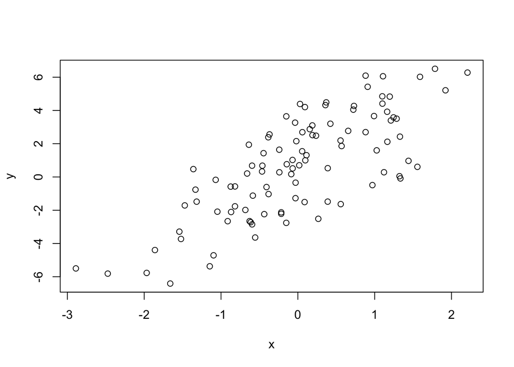

```r
plot(x,y)
```

what if x is binary

```r
set.seed(10)
x <- rbinom(100, 1, 0.5)
y <- 0.5+ 2*x + e

summary(y)
```

```
##     Min.  1st Qu.   Median     Mean  3rd Qu.     Max.
## -3.07774  0.03846  1.24754  1.51949  3.21966  6.01715
```

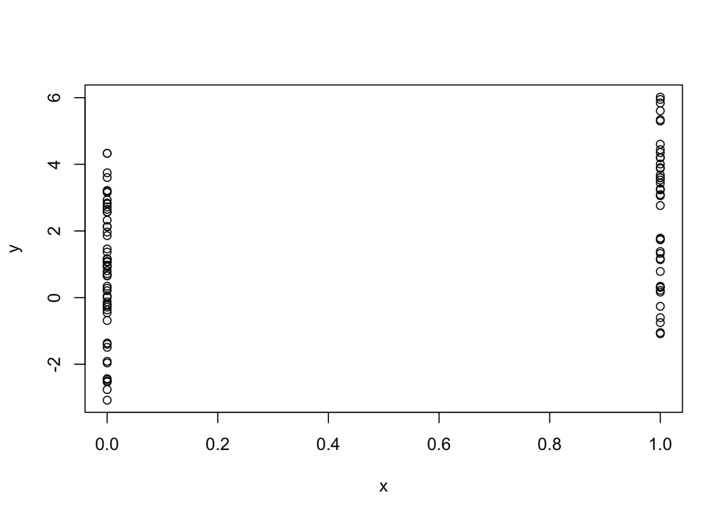

```r
plot(x,y)
```

Suppose we want to simulate from a Poisson model

```r
set.seed(1)
x <- rnorm(100)
log.mu <- 0.5+0.3*x
y <- rpois(100, exp(log.mu))

summary(y)
```

```
##    Min. 1st Qu.  Median    Mean 3rd Qu.    Max.
##    0.00    1.00    1.00    1.55    2.00    6.00
```

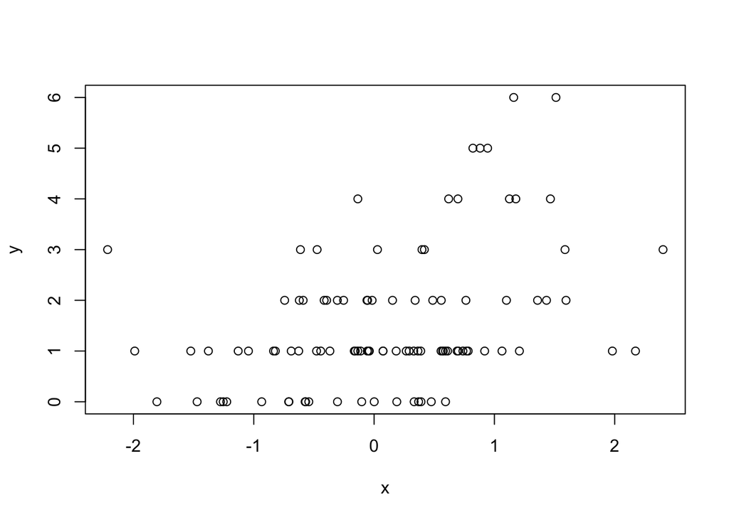

```r
plot(x,y)
```

### Simulation - Random Sampling

```r
# The sample function draws randomly from a specified set of (scalar) objects allowing you to sample from arbitrary distributions.

set.seed(1)

sample(1:10,4)
```

```
## [1] 9 4 7 1
```

```r
sample(letters,5)
```

```
## [1] "b" "w" "k" "n" "r"
```

```r
sample(1:10) # permutation
```

```
##  [1]  3  1  5  8  2  6 10  9  4  7
```

```r
sample(1:10,replace=T) # sample with replacement
```

```
##  [1]  5  9  9  5  5  2 10  9  1  4
```

### R profiler

Why is my code so slow? * profiling is a systematic way to examine how much time is spend in different parts of a program * Useful when trying to optimize your code * Often code runs fine once, but what if you have to put it in a loop for 1000 iterations? Is it still fast enough? * Profiling is better than guessing.

On optimizing your code * Getting biggest impact on speeding up code depends on knowing where the code spends most of its time * This cannot be done withou performance analysis or profiling

Using system.time() * user time: time charged to the cpu for this expression * elapsed itme:” wall clock” time

```r
system.time(readLines("http://www.jhsph.edu"))
```

```
##    user  system elapsed
##   0.027   0.009   0.818
```

The Rprof() function strarts the profiler in R * R must be compiled with profiler support ( but this is usually the case) The summaryRprof() function summarizes the output from Rprof() (otherwise its not readable) * Do not use system.teim() and Rprof() togehter or you will be sad.

# Course 8 Practical Machine Learning

## week 8.1 Prediciton

### Who predicts

- Local governments - > pension payments
- Google -> Whether you will click on an ad
- Amazon -> what movies you will watch
- Insurance companies -> what your risk of death is
- Johns Hopkins -> who will succeed in their programs

### Componets of a predictor

*question -> input data -> features -> algorithm -> parameters -> evaluation

example: start with a general question can I automatically detect emails that are SPAM that are not make it concrete Can i use quantitative characteristics of the emails to classify them as SPAM / HAM?

### Relative order of importance:

question > data > features > algorithms

colleting the right data and the data is relvant to the question you are trying to answer. Often more data > better models

Properties of good features * lead to data compression * retain relevant information * are created based on expert application knowledge

Common mistakes * trying to automate feature selection * not paying attention to data-specific quirks * throwing away information unnecessarily

Algorithms matter less than you’d think

The “Best” machine Learning method * interpretable, simple, accurate, fast ( to train and test), scalable ( easy to apply to a large dataset.)

### Prediciton is about accuracy tradeoffs

- interpretability versus accuracy
- speed versus accuracy
- simplicity versus accuracy
- scalability versus accuracy

### In sample and out of smaple error

In sample error: the error rate you get on the same data set you used to build your predictor. Sometimes called resubsititution error.

Out of smaple error: the error rate you get on a new data set. sometimes called generalization error.

Key ides 1. out of smaple error is what you care about 2. in sample error < out of smaple error 3. the reason is overfitting * matching your algorithm to the data you have.

Why more sophscated alogrithm yield higher out of sample error” * overfitting + data have two parts: signal and noise * the goal of a predictor is to find signal * you can always design a perfect in-sample predictor * you capture both signal + noise when you do that * predictor won’t perform as well on new samples

### Prdiction study design

1. Define your error rate
2. Split data into :
- training, testing, validation (optional)
3. On thetraining set pick features
- use cross-validation
4. ON the training set pick prediction function
- use cross-validation
5. If no validation
- apply 1 time to test set
6. if validation
- apply to test set and refine
- apply 1* to validation

#### Avioid small sample sizes.

- if you have a lrge sample size
- 60% training
- 20% test
- 20% validation
- if you have a medium sample size -60% training -40 % testing

*if you have a small sample size - do cross validation - report caveat of small sample size

#### some principles to remember

set the test/validaiton set aside and don’t look at it all subsets should reflect as much diversity as possible -you can also try to balance by features - but this is tricky

### types of error

sensitivity = tp/(tp+FN) 真得病的有多少可以测出来 recall

specificity = tn/(FP+TN) 真没病的有多少可以测出来

positive predictive value = TP/TP+FP 测出有病的有多少是真有病 precision negative predictive value = TN/FN+TN 测出没病的有多少是真没病

accuracy = (TP+TN)/(TP+FP+FN+TN) 测得有多准

For continuous data: mean squared error(MSE): calculate the average of the suqared differences between prediction and truth.

Root mean squared error (RMSE) square root of the previous A good measure of the error of the continuos data.

#### common error measures

1. mean squared error ( continuous data, sensitive to outliers
2. median absolute deviation (continuous data. often more robust)
3. sensity (recall)
4. specificity
5. accuracy

### Receiver Operating Charactristic

ROC curves

a common way to measure the quality or goodness of a prediction algorithm.

Why a curve? * in binary classification you are predicting one of two categories

- but your predictions are ofoten quantitative -probability of being alive
- the cutoff you choose gives different results

senstivity( recall) on the y axis (true positive rate) (1-specificity) on the x axis (false positive rate)

different point represnt different cutoff

this curve shows the tradeoff between specificity and senstivity

AUC area under the cure to compare the performace of different algothrim

if AUC =0 .5: random guessing if AUX =1 ” perfect classifer in general AUC of above 0.8 considered good

### cross validation

This lecture is about cross validation. Which is one of the most widely used tools, for detecting relevant features, and for building models. And estimating their parameters when doing machine learning.

Approach: 1. use the training set 2. split it into training/test sets 3. build a odel on the training set 4. evaluate on the test set 5. repeat and average the estimated errors

used for: 1. picking variables to include in a model 2. picking the tpe of prediction function to use 3. picking the parameters in the prediction function 4. compare different predictors

So, the different ways that people can use training and test sets. One example is they do random subsampling. So, imagine that, every observation we’re trying to predict is arrayed out along the, this axis here. And the color represents whether we include it in the training set or testing set, so again, this is only the training samples, and what we might do is just take a subsample of them, and call them the testing sample. So in this case, it’s the light gray bars here, are all the samples in this particular iteration that we call test samples. Then we would build our predictor on all the dark gray samples. And so, again, this is only within the training set. We take the dark gray samples and build a model, and then apply it to predict the light gray samples, and evaluate their accuracy. We can do this, for several different random subsamples. So this is a ra, one random sampling. And then this second row is the second random sampling. And this third row is the third random sampling. Do that over and over again, and then average what the errors will be.

Another way is called K-fold cross validation

another way is called leave one out cross validation

Considerations * for time series data, data must be used in “chunks” * for k-fold cross validation + larger k= less bias, more variance + smaller k = more bias, less variamce * random sampling must be done without replacement * random sampling with replacement is the bootstrap + underestimates of the erorr + can be corrected, but it is complicated

- if you cross-validate to pick predictors estimate you must estimate errors on independent data.

## Week 8.2 Caret package

### Caret functionality

- some preprocessing (cleanihng)
  - preProcess
- Data spliting
  - createDataPartition
  - createResample
  - createTimeSlices
- Training/testing functions
  - train
  - predict
- Model comparison
  - confusionMatrix

### Machine Learning algorithms in R

- Linear discriminant analysis
- Regression
- Naive Bayes
- Support vector machines
- Classification and regression trees
- Random forests
- Boosting
- etc.

SPAM Example: Data splitting

```r
library(caret)
# install.packages("kernlab")
library(kernlab);data(spam) # load the spam dataset
inTrain <- createDataPartition(y=spam$type,p=0.75, list=FALSE) # split the data set in to 75% training

training <- spam[inTrain,]
testing <- spam[-inTrain,]

dim(training)
```

```
## [1] 3451   58
```

SPAM Example: Fit a model

```r
set.seed(32343)
modelFit <- train(type~., data=training, method="glm")
```

[output not shown]

[output cut: 637 more lines]

[output not shown]

[output not shown]

[output cut: 79 more lines]

[output not shown]

[output not shown]

```r
modelFit
```

```
## Generalized Linear Model
##
## 3451 samples
##   57 predictor
##    2 classes: 'nonspam', 'spam'
##
## No pre-processing
## Resampling: Bootstrapped (25 reps)
## Summary of sample sizes: 3451, 3451, 3451, 3451, 3451, 3451, ...
## Resampling results:
##
##   Accuracy   Kappa
##   0.9225736  0.8371828
```

```r
modelFit$finalModel # get the details of the fitted model parameter.
```

```
##
## Call:  NULL
##
## Coefficients:
##       (Intercept)               make            address                all
##        -1.620e+00         -5.885e-01         -1.190e-01          1.661e-01
##             num3d                our               over             remove
##         2.636e+00          5.691e-01          7.279e-01          2.458e+00
##          internet              order               mail            receive
##         6.518e-01          1.059e+00          9.496e-02         -7.488e-02
##              will             people             report          addresses
##        -8.175e-02         -4.441e-02          6.955e-02          1.712e+00
##              free           business              email                you
##         9.414e-01          1.443e+00          9.566e-02          6.401e-02
##            credit               your               font             num000
##         1.407e+00          2.144e-01          2.940e-01          1.837e+00
##             money                 hp                hpl             george
##         6.259e-01         -2.089e+00         -8.787e-01         -1.129e+01
##            num650                lab               labs             telnet
##         4.358e-01         -4.073e+00         -2.792e-01         -1.282e-01
##            num857               data             num415              num85
##         2.261e+00         -7.452e-01          5.336e-01         -1.852e+00
##        technology            num1999              parts                 pm
##         1.245e+00         -2.546e-02          9.555e-01         -1.011e+00
##            direct                 cs            meeting           original
##        -2.261e-01         -5.235e+02         -2.362e+00         -1.907e+00
##           project                 re                edu              table
##        -1.599e+00         -5.858e-01         -1.619e+00         -2.120e+00
##        conference      charSemicolon   charRoundbracket  charSquarebracket
##        -3.425e+00         -1.508e+00         -4.612e-01         -8.961e-01
##   charExclamation         charDollar           charHash         capitalAve
##         6.385e-01          5.002e+00          2.195e+00          6.768e-03
##       capitalLong       capitalTotal
##         9.550e-03          6.548e-04
##
## Degrees of Freedom: 3450 Total (i.e. Null);  3393 Residual
## Null Deviance:       4628
## Residual Deviance: 1336  AIC: 1452
```

```r
predictions <- predict(modelFit, newdata=testing)
predictions
```

```
##    [1] spam    spam    spam    spam    spam    spam    spam    spam    nonspam
##   [10] spam    spam    spam    spam    spam    spam    spam    spam    spam
##   [19] spam    spam    spam    spam    spam    spam    spam    nonspam spam
##   [28] nonspam spam    spam    spam    spam    spam    spam    spam    spam
##   [37] spam    spam    spam    spam    spam    spam    spam    spam    spam
##   [46] spam    spam    spam    nonspam spam    spam    spam    spam    spam
##   [55] spam    spam    spam    spam    spam    nonspam spam    spam    spam
##   [64] spam    spam    spam    spam    spam    spam    spam    spam    spam
##   [73] spam    spam    spam    spam    spam    spam    nonspam spam    spam
##   [82] nonspam spam    spam    spam    spam    spam    spam    spam    spam
##   [91] spam    spam    spam    spam    spam    spam    spam    nonspam spam
##  [100] spam    spam    spam    spam    spam    spam    spam    spam    spam
##  [109] spam    spam    spam    nonspam spam    spam    spam    spam    spam
##  [118] nonspam spam    nonspam nonspam spam    nonspam spam    spam    spam
##  [127] spam    spam    spam    spam    spam    spam    spam    spam    spam
```

[output cut: 114 more lines]

SPAM Example: Confusion Matrix

```r
# confusionMatrix(predicitons, testing$type)
```

### Data slicing

SPAM Example: Data splitting

Use createDataPartition to separate training set and test set.

```r
library(caret)
library(kernlab);data(spam) # load the spam dataset

# create an indicator function.
inTrain <- createDataPartition(y=spam$type,p=0.75, list=FALSE) # split the data set in to 75% training

training <- spam[inTrain,]
testing <- spam[-inTrain,]

dim(training)
```

```
## [1] 3451   58
```

SPAM Example: K-fold of the training set

```r
set.seed(32323)
folds <- createFolds(y=spam$type, k=10, list=T, returnTrain=T)

sapply(folds, length)
```

```
## Fold01 Fold02 Fold03 Fold04 Fold05 Fold06 Fold07 Fold08 Fold09 Fold10
##   4140   4142   4141   4140   4141   4141   4142   4141   4141   4140
```

```r
folds[[1]][1:10]
```

```
##  [1]  1  2  4  5  6  7  8  9 10 11
```

```r
table(unlist(folds)) # each observation to be used in 9 of the folds.
```

```
##
##    1    2    3    4    5    6    7    8    9   10   11   12   13   14   15   16
##    9    9    9    9    9    9    9    9    9    9    9    9    9    9    9    9
##   17   18   19   20   21   22   23   24   25   26   27   28   29   30   31   32
##    9    9    9    9    9    9    9    9    9    9    9    9    9    9    9    9
##   33   34   35   36   37   38   39   40   41   42   43   44   45   46   47   48
##    9    9    9    9    9    9    9    9    9    9    9    9    9    9    9    9
##   49   50   51   52   53   54   55   56   57   58   59   60   61   62   63   64
##    9    9    9    9    9    9    9    9    9    9    9    9    9    9    9    9
##   65   66   67   68   69   70   71   72   73   74   75   76   77   78   79   80
##    9    9    9    9    9    9    9    9    9    9    9    9    9    9    9    9
##   81   82   83   84   85   86   87   88   89   90   91   92   93   94   95   96
##    9    9    9    9    9    9    9    9    9    9    9    9    9    9    9    9
##   97   98   99  100  101  102  103  104  105  106  107  108  109  110  111  112
##    9    9    9    9    9    9    9    9    9    9    9    9    9    9    9    9
```

[output cut: 562 more lines]

```r
# returntraina: logical. When true, the values returned are the sample positions corresponding to the data used during training. This argument only works in conjunction with list = TRUE
```

SPAM Example: Return test

```r
set.seed(32323)
folds <- createFolds(y=spam$type, k=10, list=T, returnTrain=F)
sapply(folds, length)
```

```
## Fold01 Fold02 Fold03 Fold04 Fold05 Fold06 Fold07 Fold08 Fold09 Fold10
##    461    459    460    461    460    460    459    460    460    461
```

```r
folds[[1]][1:10]
```

```
##  [1]  3 19 33 38 44 51 66 67 72 83
```

```r
# if return Train is fals, then it would be ten folds for the test set.
```

SPAM Example: Resampling

```r
set.seed(32323)
folds <- createResample(y=spam$type, times=10,list=T)
sapply(folds, length)
```

```
## Resample01 Resample02 Resample03 Resample04 Resample05 Resample06 Resample07
##       4601       4601       4601       4601       4601       4601       4601
## Resample08 Resample09 Resample10
##       4601       4601       4601
```

```r
folds[[1]][1:10]
```

```
##  [1] 1 1 2 2 3 3 4 5 5 7
```

```r
# sampling with replacement.
```

SPAM Example: Time slices

```r
set.seed(32323)
tme <- 1:1000
folds <- createTimeSlices(y=tme, initialWindow = 20 , horizon=10)
names(folds)
```

```
## [1] "train" "test"
```

```r
folds$train[[1]]
```

```
##  [1]  1  2  3  4  5  6  7  8  9 10 11 12 13 14 15 16 17 18 19 20
```

```r
folds$test[[1]]
```

```
##  [1] 21 22 23 24 25 26 27 28 29 30
```

### Training options

```r
library(caret)
library(kernlab);data(spam) # load the spam dataset

# create an indicator function.
inTrain <- createDataPartition(y=spam$type,p=0.75, list=FALSE) # split the data set in to 75% training

training <- spam[inTrain,]
testing <- spam[-inTrain,]

dim(training)
```

```
## [1] 3451   58
```

```r
modelFit <- train(type~., data=training, method="glm")
```

[output not shown]

[output cut: 347 more lines]

[output not shown]

[output not shown]

```r
modelFit
```

```
## Generalized Linear Model
##
## 3451 samples
##   57 predictor
##    2 classes: 'nonspam', 'spam'
##
## No pre-processing
## Resampling: Bootstrapped (25 reps)
## Summary of sample sizes: 3451, 3451, 3451, 3451, 3451, 3451, ...
## Resampling results:
##
##   Accuracy   Kappa
##   0.9241196  0.8395629
```

### Ploting predictors

```r
# install.packages("ISLR")
library(ISLR)
```

```r
library(ggplot2)
library(caret)
data(Wage)
summary(Wage)
```

```
##       year           age                     maritl           race
##  Min.   :2003   Min.   :18.00   1. Never Married: 648   1. White:2480
##  1st Qu.:2004   1st Qu.:33.75   2. Married      :2074   2. Black: 293
##  Median :2006   Median :42.00   3. Widowed      :  19   3. Asian: 190
##  Mean   :2006   Mean   :42.41   4. Divorced     : 204   4. Other:  37
##  3rd Qu.:2008   3rd Qu.:51.00   5. Separated    :  55
##  Max.   :2009   Max.   :80.00
##
##               education                     region               jobclass
##  1. < HS Grad      :268   2. Middle Atlantic   :3000   1. Industrial :1544
##  2. HS Grad        :971   1. New England       :   0   2. Information:1456
##  3. Some College   :650   3. East North Central:   0
##  4. College Grad   :685   4. West North Central:   0
##  5. Advanced Degree:426   5. South Atlantic    :   0
##                           6. East South Central:   0
##                           (Other)              :   0
##             health      health_ins      logwage           wage
##  1. <=Good     : 858   1. Yes:2083   Min.   :3.000   Min.   : 20.09
##  2. >=Very Good:2142   2. No : 917   1st Qu.:4.447   1st Qu.: 85.38
##                                      Median :4.653   Median :104.92
##                                      Mean   :4.654   Mean   :111.70
##                                      3rd Qu.:4.857   3rd Qu.:128.68
##                                      Max.   :5.763   Max.   :318.34
##
```

```r
# get training/test sets
inTrain <- createDataPartition(y=Wage$wage, p=0.7, list=F)

training <- Wage[inTrain,]
testing <- Wage[-inTrain,]

dim(training);
```

```
## [1] 2102   11
```

```r
dim(testing)
```

```
## [1] 898  11
```

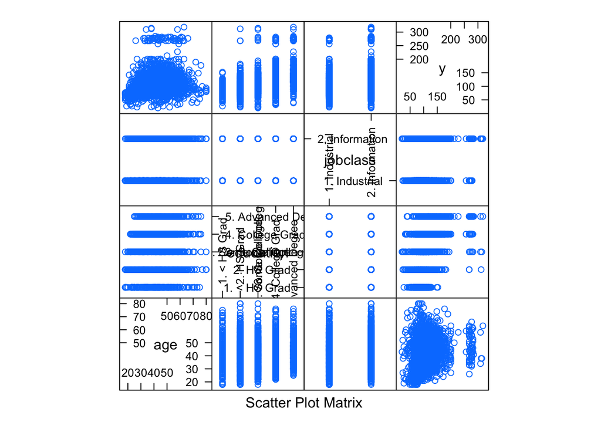

```r
# feature plot( caret package )
featurePlot(x=training[,c("age","education","jobclass")],
  y=training$wage,
  plot="pairs")
```

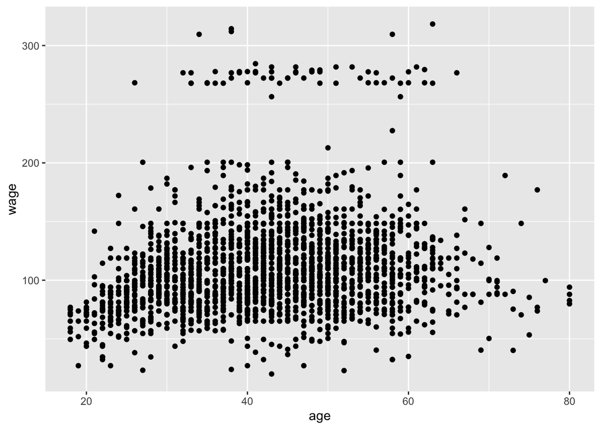

```r
# Qplot (ggplot2 package)
qplot(age,wage,data=training)
```

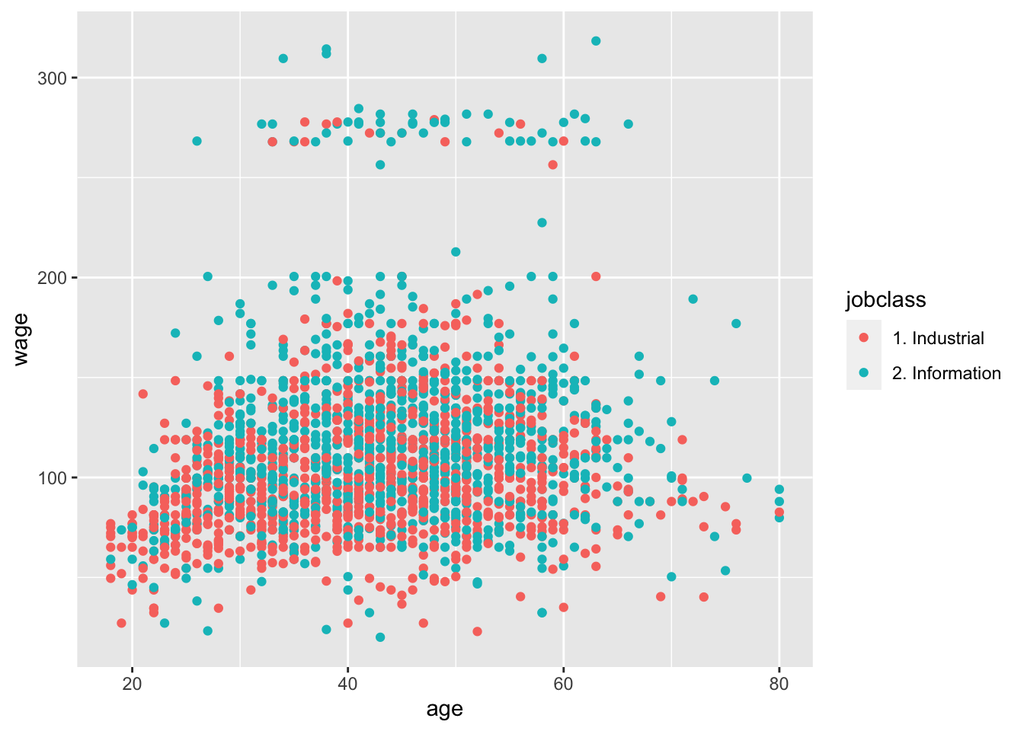

```r
# Qplot with color (ggplot2 package)
qplot(age,wage,colour=jobclass, data=training)
```

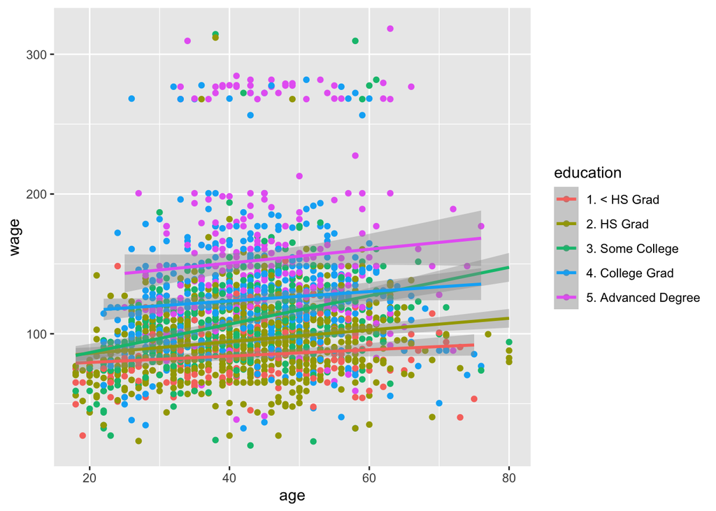

[output not shown]

[output cut: 347 more lines]

[output not shown]

```r
# add regression smoothers (ggplot2 package)
qq <- qplot(age, wage, colour=education, data=training)
qq + geom_smooth(method='lm', formula=y~x)
```

```r
# cut2, makin factors (Hmisc package)
# install.packages("Hmisc")
# change wage variable into different category
library(Hmisc)
cutWage <- cut2(training$wage, g=3)
table(cutWage)
```

```
## cutWage
## [ 20.1, 91.7) [ 91.7,118.9) [118.9,318.3]
##           701           728           673
```

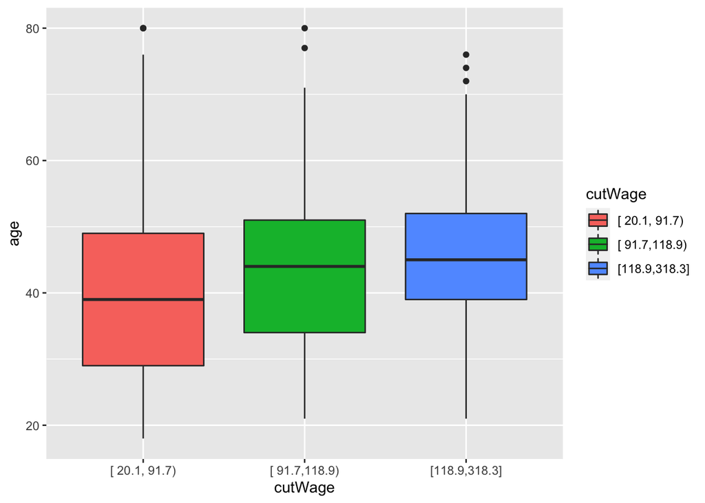

[output not shown]

[output cut: 213 more lines]

[output not shown]

```r
p1 <- qplot(cutWage, age, data=training, fill=cutWage, geom=c("boxplot"))

p1
```

```r
# Boxplots with points overlayed
p2 <- qplot(cutWage, age, data=training, fill=cutWage,geom=c("boxplot","jitter"))

# put two picures together.
# grid.arrange(p1,p2,ncol=2)


# Tables

t1 <- table(cutWage,training$jobclass)
t1
```

```
##
## cutWage         1. Industrial 2. Information
##   [ 20.1, 91.7)           442            259
##   [ 91.7,118.9)           370            358
##   [118.9,318.3]           254            419
```

```r
prop.table(t1,1) # proportion
```

```
##
## cutWage         1. Industrial 2. Information
##   [ 20.1, 91.7)     0.6305278      0.3694722
##   [ 91.7,118.9)     0.5082418      0.4917582
##   [118.9,318.3]     0.3774146      0.6225854
```

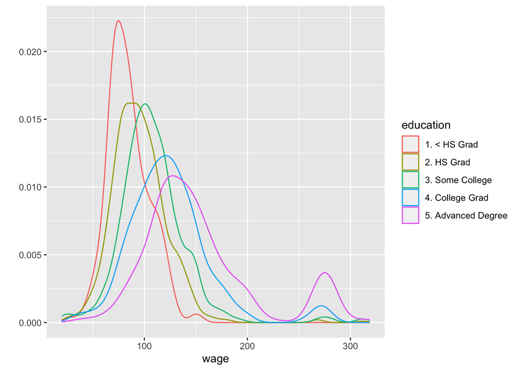

[output not shown]

[output cut: 79 more lines]

[output not shown]

```r
# Density plots

qplot(wage, colour=education, data=training, geom="density")
```

Notes: * Make your plots only in the training set + Don’t use the test set for exploration! * Things you should be looking for + imbalance in outcomes/predictors + outliers + groups of points not explained by a predictor + skewed variables

### Basic preprocessing the predicator

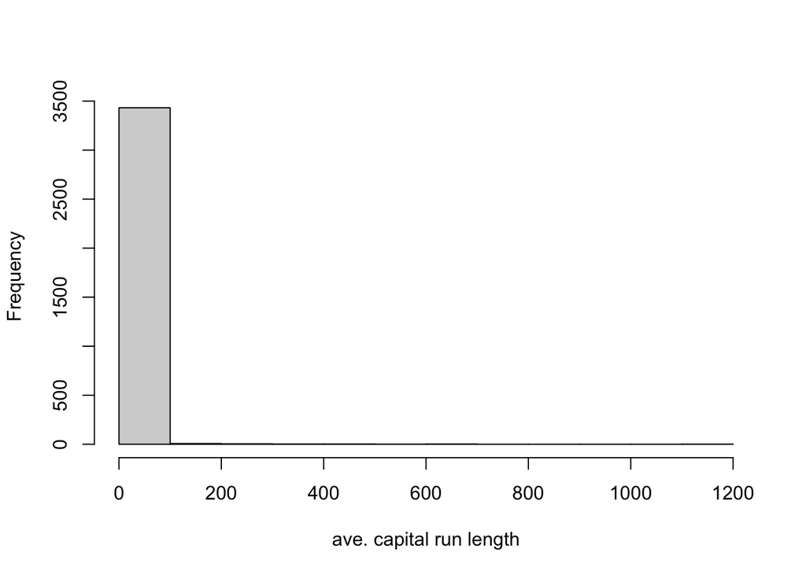

```r
library(caret)
library(kernlab);data(spam) # load the spam dataset

# create an indicator function.
inTrain <- createDataPartition(y=spam$type,p=0.75, list=FALSE) # split the data set in to 75% training

training <- spam[inTrain,]
testing <- spam[-inTrain,]

hist(training$capitalAve, main="", xlab="ave. capital run length")
```

```r
mean(training$capitalAve)
```

```
## [1] 5.452347
```

```r
sd(training$capitalAve)
```

```
## [1] 32.04618
```

```r
# we found that variable is skewed and highly variable

# standardizing

trainCapAve <- training$capitalAve
trainCapAveS <- (trainCapAve - mean(trainCapAve))/sd(trainCapAve)
mean(trainCapAveS)
```

```
## [1] 3.3215e-16
```

```r
sd(trainCapAveS)
```

```
## [1] 1
```

```r
# standardizing -test
testCapAve <- testing$capitalAve
testCapAveS <-(testCapAve - mean(trainCapAve))/sd(trainCapAve)
mean(testCapAveS)
```

```
## [1] -0.0325641
```

```r
sd(testCapAveS)
```

```
## [1] 0.9598581
```

```r
# standardizing - preProcess function (built in caret)
preObj <- preProcess(training[,-58], method = c("center","scale")) # center every variable and scale every variable except for the outcome variable

trainCapAveS <- predict(preObj, training[,-58])$capitalAve
mean(trainCapAveS)
```

```
## [1] 3.3215e-16
```

```r
sd(trainCapAveS)
```

```
## [1] 1
```

```r
# apply the same preproces to the testset!

testCapAveS <- predict(preObj, testing[,-58])$capitalAve
mean(testCapAveS)
```

```
## [1] -0.0325641
```

```r
sd(testCapAveS)
```

```
## [1] 0.9598581
```

```r
# you can pas the preProcess in the train as an argument
modelFit <- train(type~., data=training, preProcess=c("center","scale"), method="glm")
```

[output not shown]

[output cut: 347 more lines]

[output not shown]

[output not shown]

```r
modelFit
```

```
## Generalized Linear Model
##
## 3451 samples
##   57 predictor
##    2 classes: 'nonspam', 'spam'
##
## Pre-processing: centered (57), scaled (57)
## Resampling: Bootstrapped (25 reps)
## Summary of sample sizes: 3451, 3451, 3451, 3451, 3451, 3451, ...
## Resampling results:
##
##   Accuracy   Kappa
##   0.9194936  0.8308233
```

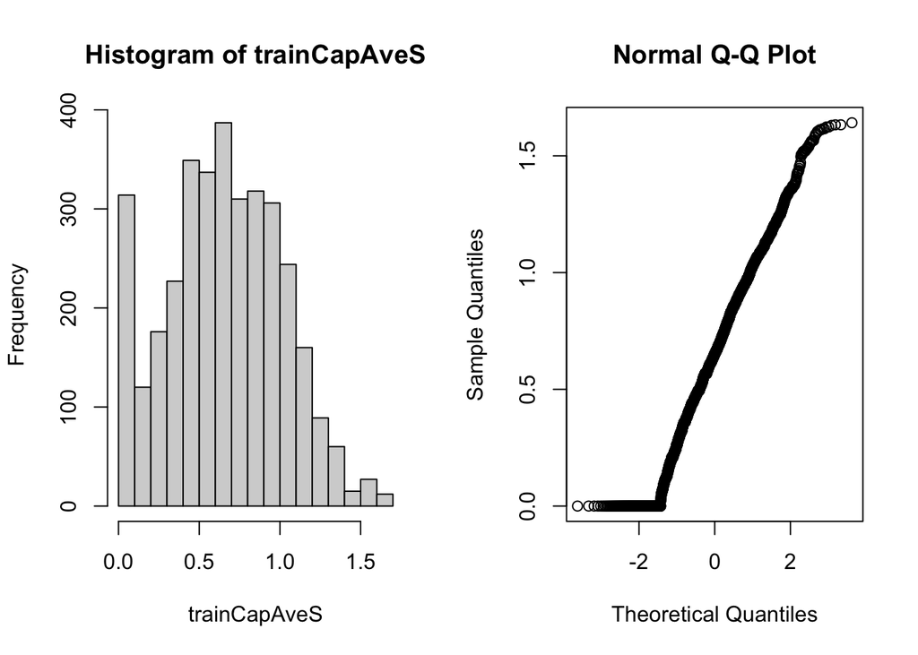

```r
# another way to standare variable
# standardizing - Box-Cox transforms

preObj <- preProcess(training[,-58], method=c("BoxCox"))
trainCapAveS <- predict(preObj, training[,-58])$capitalAve
par(mfrow=c(1,2));
hist(trainCapAveS); qqnorm(trainCapAveS)
```

```r
# fill the missing data.
set.seed(13343)

# make some values NA
training$capAve <- training$capitalAve
selectNA <- rbinom(dim(training)[1], size=1,prob=0.05)==1
training$capAve[selectNA]<-NA

# impute and Standardize
# install.packages("RANN")
library(RANN)


preObj <- preProcess(training[,-58], method="knnImpute")
capAve <-predict(preObj, training[,-58])$capAve

# Standardize true values
capAveTruth <- training$capitalAve
capAveTruth <- (capAveTruth-mean(capAveTruth))/sd(capAveTruth)

quantile(capAve-capAveTruth) # compare imputed and actual
```

```
##           0%          25%          50%          75%         100%
## -1.522799841  0.001799650  0.002202549  0.002389961  0.708600118
```

Notes and further reading

Training and test must be preocssed in the same way test transformations will likely be imperfect + especially if the test/training sets collected at different times careful when transforming factor variables*